Pong Yui Yi Monica SID:20853295

# Chapter 2

### question 8

(a). Use the pd.read_csv() function to read the data into Python. Call the loaded data college. Make sure that you have the directory set to the correct location for the data.

```python
import matplotlib.pyplot as plt
import seaborn as sns
import pandas as pd
import numpy as np
```

```python
college = pd.read_csv("College.csv")
college
```

|  | Unnamed: 0 | Private | Apps | Accept | Enroll | Top10perc | Top25perc | F.Undergrad | P.Undergrad | Outstate | Room.Board | Books | Personal | PhD | Terminal | S.F.Ratio | perc.alumni | Expend | Grad.Rate |
| --- | --- | --- | --- | --- | --- | --- | --- | --- | --- | --- | --- | --- | --- | --- | --- | --- | --- | --- | --- |
| 0 | Abilene Christian University | Yes | 1660 | 1232 | 721 | 23 | 52 | 2885 | 537 | 7440 | 3300 | 450 | 2200 | 70 | 78 | 18.1 | 12 | 7041 | 60 |
| 1 | Adelphi University | Yes | 2186 | 1924 | 512 | 16 | 29 | 2683 | 1227 | 12280 | 6450 | 750 | 1500 | 29 | 30 | 12.2 | 16 | 10527 | 56 |
| 2 | Adrian College | Yes | 1428 | 1097 | 336 | 22 | 50 | 1036 | 99 | 11250 | 3750 | 400 | 1165 | 53 | 66 | 12.9 | 30 | 8735 | 54 |
| 3 | Agnes Scott College | Yes | 417 | 349 | 137 | 60 | 89 | 510 | 63 | 12960 | 5450 | 450 | 875 | 92 | 97 | 7.7 | 37 | 19016 | 59 |
| 4 | Alaska Pacific University | Yes | 193 | 146 | 55 | 16 | 44 | 249 | 869 | 7560 | 4120 | 800 | 1500 | 76 | 72 | 11.9 | 2 | 10922 | 15 |
| ... | ... | ... | ... | ... | ... | ... | ... | ... | ... | ... | ... | ... | ... | ... | ... | ... | ... | ... | ... |
| 772 | Worcester State College | No | 2197 | 1515 | 543 | 4 | 26 | 3089 | 2029 | 6797 | 3900 | 500 | 1200 | 60 | 60 | 21.0 | 14 | 4469 | 40 |
| 773 | Xavier University | Yes | 1959 | 1805 | 695 | 24 | 47 | 2849 | 1107 | 11520 | 4960 | 600 | 1250 | 73 | 75 | 13.3 | 31 | 9189 | 83 |
| 774 | Xavier University of Louisiana | Yes | 2097 | 1915 | 695 | 34 | 61 | 2793 | 166 | 6900 | 4200 | 617 | 781 | 67 | 75 | 14.4 | 20 | 8323 | 49 |
| 775 | Yale University | Yes | 10705 | 2453 | 1317 | 95 | 99 | 5217 | 83 | 19840 | 6510 | 630 | 2115 | 96 | 96 | 5.8 | 49 | 40386 | 99 |
| 776 | York College of Pennsylvania | Yes | 2989 | 1855 | 691 | 28 | 63 | 2988 | 1726 | 4990 | 3560 | 500 | 1250 | 75 | 75 | 18.1 | 28 | 4509 | 99 |

777 rows × 19 columns

(b) Look at the data used in the notebook by creating and running a new cell with just the code college in it. You should notice that the first column is just the name of each university in a column named something like Unnamed: 0. We don’t really want pandas to treat this as data. However, it may be handy to have these names for later. Try the following commands and similarly look at the resulting data frames:

```python
college2 = pd.read_csv('College.csv', index_col=0)
college3 = college.rename({'Unnamed: 0': 'College'},axis=1)
college3 = college3.set_index('College')
college = college3
college
```

| College | Private | Apps | Accept | Enroll | Top10perc | Top25perc | F.Undergrad | P.Undergrad | Outstate | Room.Board | Books | Personal | PhD | Terminal | S.F.Ratio | perc.alumni | Expend | Grad.Rate |
| --- | --- | --- | --- | --- | --- | --- | --- | --- | --- | --- | --- | --- | --- | --- | --- | --- | --- | --- |
| Abilene Christian University | Yes | 1660 | 1232 | 721 | 23 | 52 | 2885 | 537 | 7440 | 3300 | 450 | 2200 | 70 | 78 | 18.1 | 12 | 7041 | 60 |
| Adelphi University | Yes | 2186 | 1924 | 512 | 16 | 29 | 2683 | 1227 | 12280 | 6450 | 750 | 1500 | 29 | 30 | 12.2 | 16 | 10527 | 56 |
| Adrian College | Yes | 1428 | 1097 | 336 | 22 | 50 | 1036 | 99 | 11250 | 3750 | 400 | 1165 | 53 | 66 | 12.9 | 30 | 8735 | 54 |
| Agnes Scott College | Yes | 417 | 349 | 137 | 60 | 89 | 510 | 63 | 12960 | 5450 | 450 | 875 | 92 | 97 | 7.7 | 37 | 19016 | 59 |
| Alaska Pacific University | Yes | 193 | 146 | 55 | 16 | 44 | 249 | 869 | 7560 | 4120 | 800 | 1500 | 76 | 72 | 11.9 | 2 | 10922 | 15 |
| ... | ... | ... | ... | ... | ... | ... | ... | ... | ... | ... | ... | ... | ... | ... | ... | ... | ... | ... |
| Worcester State College | No | 2197 | 1515 | 543 | 4 | 26 | 3089 | 2029 | 6797 | 3900 | 500 | 1200 | 60 | 60 | 21.0 | 14 | 4469 | 40 |
| Xavier University | Yes | 1959 | 1805 | 695 | 24 | 47 | 2849 | 1107 | 11520 | 4960 | 600 | 1250 | 73 | 75 | 13.3 | 31 | 9189 | 83 |
| Xavier University of Louisiana | Yes | 2097 | 1915 | 695 | 34 | 61 | 2793 | 166 | 6900 | 4200 | 617 | 781 | 67 | 75 | 14.4 | 20 | 8323 | 49 |
| Yale University | Yes | 10705 | 2453 | 1317 | 95 | 99 | 5217 | 83 | 19840 | 6510 | 630 | 2115 | 96 | 96 | 5.8 | 49 | 40386 | 99 |
| York College of Pennsylvania | Yes | 2989 | 1855 | 691 | 28 | 63 | 2988 | 1726 | 4990 | 3560 | 500 | 1250 | 75 | 75 | 18.1 | 28 | 4509 | 99 |

777 rows × 18 columns

(c). Use the describe() method of to produce a numerical summary of the variables in the data set.

```python
college.describe(include='number')
```

|  | Apps | Accept | Enroll | Top10perc | Top25perc | F.Undergrad | P.Undergrad | Outstate | Room.Board | Books | Personal | PhD | Terminal | S.F.Ratio | perc.alumni | Expend | Grad.Rate |
| --- | --- | --- | --- | --- | --- | --- | --- | --- | --- | --- | --- | --- | --- | --- | --- | --- | --- |
| count | 777.000000 | 777.000000 | 777.000000 | 777.000000 | 777.000000 | 777.000000 | 777.000000 | 777.000000 | 777.000000 | 777.000000 | 777.000000 | 777.000000 | 777.000000 | 777.000000 | 777.000000 | 777.000000 | 777.00000 |
| mean | 3001.638353 | 2018.804376 | 779.972973 | 27.558559 | 55.796654 | 3699.907336 | 855.298584 | 10440.669241 | 4357.526384 | 549.380952 | 1340.642214 | 72.660232 | 79.702703 | 14.089704 | 22.743887 | 9660.171171 | 65.46332 |
| std | 3870.201484 | 2451.113971 | 929.176190 | 17.640364 | 19.804778 | 4850.420531 | 1522.431887 | 4023.016484 | 1096.696416 | 165.105360 | 677.071454 | 16.328155 | 14.722359 | 3.958349 | 12.391801 | 5221.768440 | 17.17771 |
| min | 81.000000 | 72.000000 | 35.000000 | 1.000000 | 9.000000 | 139.000000 | 1.000000 | 2340.000000 | 1780.000000 | 96.000000 | 250.000000 | 8.000000 | 24.000000 | 2.500000 | 0.000000 | 3186.000000 | 10.00000 |
| 25% | 776.000000 | 604.000000 | 242.000000 | 15.000000 | 41.000000 | 992.000000 | 95.000000 | 7320.000000 | 3597.000000 | 470.000000 | 850.000000 | 62.000000 | 71.000000 | 11.500000 | 13.000000 | 6751.000000 | 53.00000 |
| 50% | 1558.000000 | 1110.000000 | 434.000000 | 23.000000 | 54.000000 | 1707.000000 | 353.000000 | 9990.000000 | 4200.000000 | 500.000000 | 1200.000000 | 75.000000 | 82.000000 | 13.600000 | 21.000000 | 8377.000000 | 65.00000 |
| 75% | 3624.000000 | 2424.000000 | 902.000000 | 35.000000 | 69.000000 | 4005.000000 | 967.000000 | 12925.000000 | 5050.000000 | 600.000000 | 1700.000000 | 85.000000 | 92.000000 | 16.500000 | 31.000000 | 10830.000000 | 78.00000 |
| max | 48094.000000 | 26330.000000 | 6392.000000 | 96.000000 | 100.000000 | 31643.000000 | 21836.000000 | 21700.000000 | 8124.000000 | 2340.000000 | 6800.000000 | 103.000000 | 100.000000 | 39.800000 | 64.000000 | 56233.000000 | 118.00000 |

(d) Use the pd.plotting.scatter_matrix() function to produce a scatterplot matrix of the first columns [Top10perc, Apps, Enroll]. Recall that you can reference a list C of columns of a data frame A using A[C].

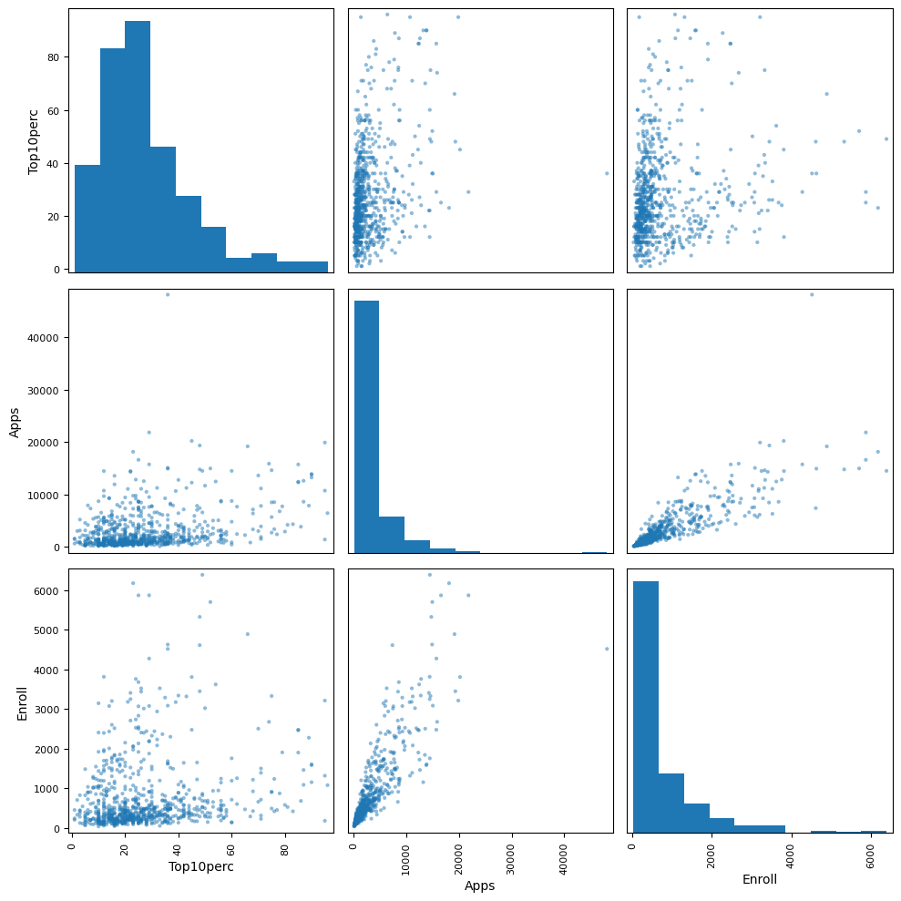

```python
columns_to_plot = ['Top10perc', 'Apps', 'Enroll']
pd.plotting.scatter_matrix(college[columns_to_plot], figsize=(10, 10))
plt.tight_layout()
plt.show()
```

(e) Use the boxplot() method of college to produce side-by-side boxplots of Outstate versus Private.

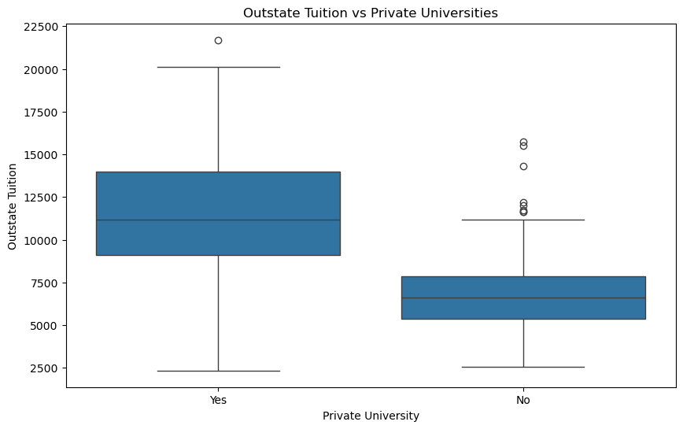

```python
plt.figure(figsize=(10, 6))
sns.boxplot(x='Private', y='Outstate', data=college)
plt.title('Outstate Tuition vs Private Universities')
plt.xlabel('Private University')
plt.ylabel('Outstate Tuition')
plt.show()
```

(f) Create a new qualitative variable, called Elite, by binning the Top10perc variable into two groups based on whether or not the proportion of students coming from the top 10% of their high school classes exceeds 50%.

college['Elite'] = pd.cut(college['Top10perc'], [0,0.5,1], labels=['No', 'Yes'])

Use the value_counts() method of college['Elite'] to see how many elite universities there are. Finally, use the boxplot() method again to produce side-by-side boxplots of Outstate versus Elite.

```python
college['Elite'] = pd.cut(college['Top10perc'],[0,0.5,1],labels=['No', 'Yes'])
college['Elite'] = college['Elite'].fillna('No')
college.head()
```

| College | Private | Apps | Accept | Enroll | Top10perc | Top25perc | F.Undergrad | P.Undergrad | Outstate | Room.Board | Books | Personal | PhD | Terminal | S.F.Ratio | perc.alumni | Expend | Grad.Rate | Elite |
| --- | --- | --- | --- | --- | --- | --- | --- | --- | --- | --- | --- | --- | --- | --- | --- | --- | --- | --- | --- |
| Abilene Christian University | Yes | 1660 | 1232 | 721 | 23 | 52 | 2885 | 537 | 7440 | 3300 | 450 | 2200 | 70 | 78 | 18.1 | 12 | 7041 | 60 | No |
| Adelphi University | Yes | 2186 | 1924 | 512 | 16 | 29 | 2683 | 1227 | 12280 | 6450 | 750 | 1500 | 29 | 30 | 12.2 | 16 | 10527 | 56 | No |
| Adrian College | Yes | 1428 | 1097 | 336 | 22 | 50 | 1036 | 99 | 11250 | 3750 | 400 | 1165 | 53 | 66 | 12.9 | 30 | 8735 | 54 | No |
| Agnes Scott College | Yes | 417 | 349 | 137 | 60 | 89 | 510 | 63 | 12960 | 5450 | 450 | 875 | 92 | 97 | 7.7 | 37 | 19016 | 59 | No |
| Alaska Pacific University | Yes | 193 | 146 | 55 | 16 | 44 | 249 | 869 | 7560 | 4120 | 800 | 1500 | 76 | 72 | 11.9 | 2 | 10922 | 15 | No |

```python
college['Elite'].value_counts()
```

```
Elite
No     774
Yes      3
Name: count, dtype: int64
```

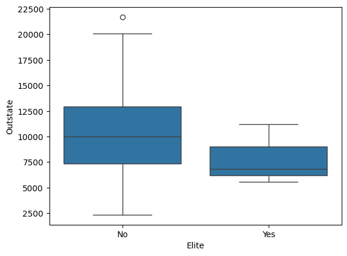

```python
sns.boxplot(x=college['Elite'], y=college['Outstate'])
```

(g) Use the plot.hist() method of college to produce some histograms with differing numbers of bins for a few of the quantitative variables. The command plt.subplots(2, 2) may be useful: it will divide the plot window into four regions so that four plots can be made simultaneously. By changing the arguments you can divide the screen up in other combinations.

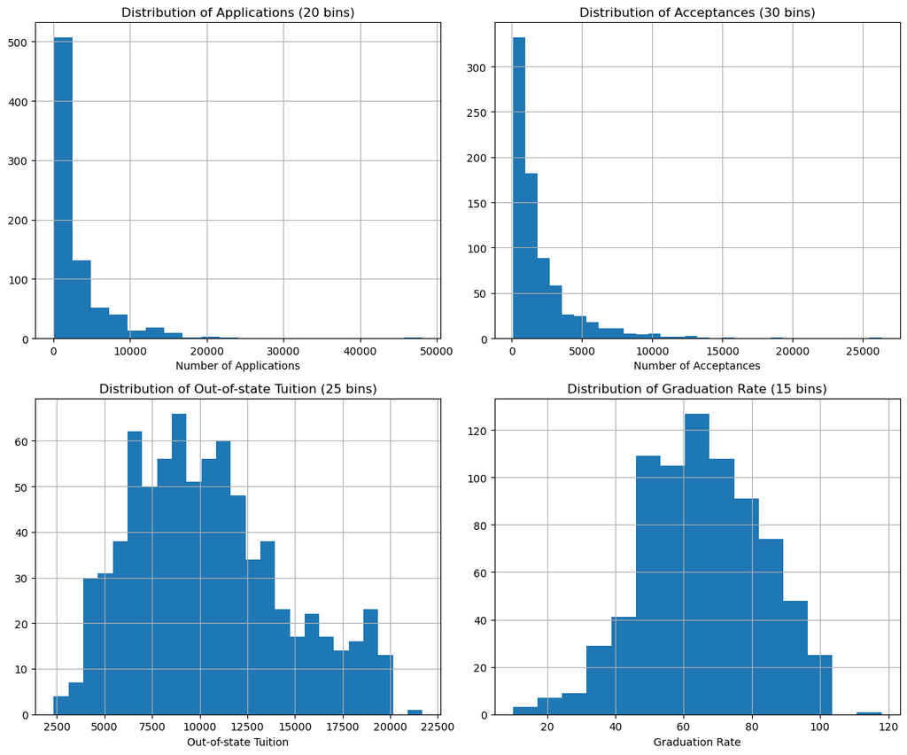

```python
fig, axes = plt.subplots(2, 2, figsize=(12, 10))

college['Apps'].hist(bins=20, ax=axes[0, 0])
axes[0, 0].set_title('Distribution of Applications (20 bins)')
axes[0, 0].set_xlabel('Number of Applications')

college['Accept'].hist(bins=30, ax=axes[0, 1])
axes[0, 1].set_title('Distribution of Acceptances (30 bins)')
axes[0, 1].set_xlabel('Number of Acceptances')

college['Outstate'].hist(bins=25, ax=axes[1, 0])
axes[1, 0].set_title('Distribution of Out-of-state Tuition (25 bins)')
axes[1, 0].set_xlabel('Out-of-state Tuition')

college['Grad.Rate'].hist(bins=15, ax=axes[1, 1])
axes[1, 1].set_title('Distribution of Graduation Rate (15 bins)')
axes[1, 1].set_xlabel('Graduation Rate')

plt.tight_layout()
plt.show()
```

(h) Continue exploring the data, and provide a brief summary of what you discover.

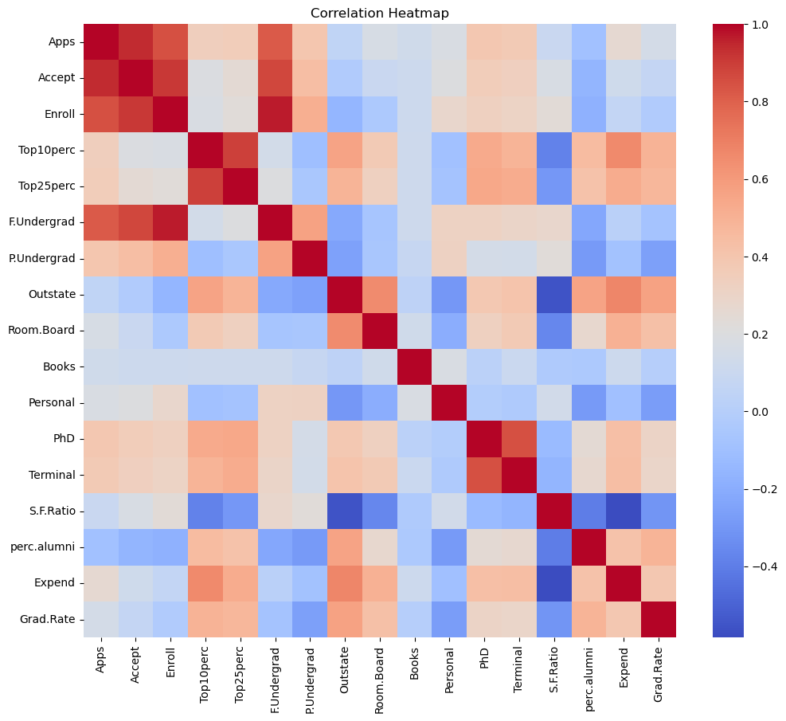

```
Some interesting correlations observed:
Outstate       1.000000
Expend         0.672779
Room.Board     0.654256
Grad.Rate      0.571290
perc.alumni    0.566262
Name: Outstate, dtype: float64
Grad.Rate      1.000000
Outstate       0.571290
Top10perc      0.494989
perc.alumni    0.490898
Top25perc      0.477281
Name: Grad.Rate, dtype: float64
```

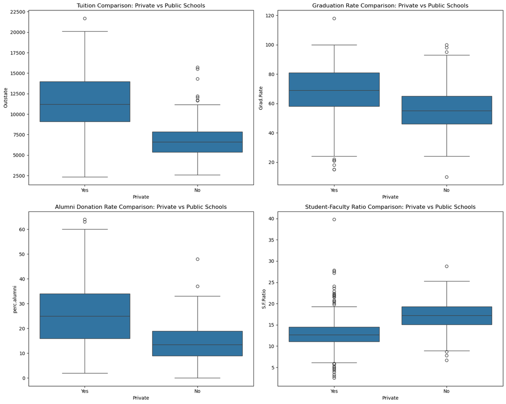

```
Potential outliers:
                  Private  Apps  Accept  Enroll  Top10perc  Top25perc  \
College
Cazenovia College     Yes  3847    3433     527          9         35

                   F.Undergrad  P.Undergrad  Outstate  Room.Board  Books  \
College
Cazenovia College         1010           12      9384        4840    600

                   Personal  PhD  Terminal  S.F.Ratio  perc.alumni  Expend  \
College
Cazenovia College       500   22        47       14.3           20    7697

                   Grad.Rate Elite
College
Cazenovia College        118    No
```

```python
# 1. Examine correlations between numerical variables
numeric_columns = college.select_dtypes(include=[np.number])
correlation_matrix = numeric_columns.corr()
plt.figure(figsize=(12, 10))
sns.heatmap(correlation_matrix, annot=False, cmap='coolwarm')
plt.title('Correlation Heatmap')
plt.show()

print("Some interesting correlations observed:")
print(correlation_matrix['Outstate'].sort_values(ascending=False).head())
print(correlation_matrix['Grad.Rate'].sort_values(ascending=False).head())

# 2. Compare private and public schools
fig, axes = plt.subplots(2, 2, figsize=(15, 12))

sns.boxplot(x='Private', y='Outstate', data=college, ax=axes[0, 0])
axes[0, 0].set_title('Tuition Comparison: Private vs Public Schools')

sns.boxplot(x='Private', y='Grad.Rate', data=college, ax=axes[0, 1])
axes[0, 1].set_title('Graduation Rate Comparison: Private vs Public Schools')

sns.boxplot(x='Private', y='perc.alumni', data=college, ax=axes[1, 0])
axes[1, 0].set_title('Alumni Donation Rate Comparison: Private vs Public Schools')

sns.boxplot(x='Private', y='S.F.Ratio', data=college, ax=axes[1, 1])
axes[1, 1].set_title('Student-Faculty Ratio Comparison: Private vs Public Schools')

plt.tight_layout()
plt.show()

# 3. Explore potential outliers
print("\nPotential outliers:")
print(college[college['Grad.Rate'] > 100])
```

**Summary of data exploration:**

1. Tuition fees are positively correlated with school reputation indicators (e.g., Top10perc, Top25perc).
2. Private schools generally have higher tuition fees but also higher graduation rates and alumni donation rates compared to public schools.
3. One school was found to have a graduation rate over 100%, which might be a data error.
4. There's a strong positive correlation between tuition fees and school expenditure, suggesting higher fees may reflect more educational resources.
5. Student-faculty ratio is negatively correlated with other quality indicators, implying that lower ratios might lead to better educational quality.

### question 10

(a) To begin, load in the Boston data set, which is part of the ISLP library.

```python
import pandas as pd
import seaborn as sns
import numpy as np
import matplotlib.pyplot as plt
```

```python
from ISLP import load_data
boston = load_data('Boston')
boston.head()
```

|  | crim | zn | indus | chas | nox | rm | age | dis | rad | tax | ptratio | lstat | medv |
| --- | --- | --- | --- | --- | --- | --- | --- | --- | --- | --- | --- | --- | --- |
| 0 | 0.00632 | 18.0 | 2.31 | 0 | 0.538 | 6.575 | 65.2 | 4.0900 | 1 | 296 | 15.3 | 4.98 | 24.0 |
| 1 | 0.02731 | 0.0 | 7.07 | 0 | 0.469 | 6.421 | 78.9 | 4.9671 | 2 | 242 | 17.8 | 9.14 | 21.6 |
| 2 | 0.02729 | 0.0 | 7.07 | 0 | 0.469 | 7.185 | 61.1 | 4.9671 | 2 | 242 | 17.8 | 4.03 | 34.7 |
| 3 | 0.03237 | 0.0 | 2.18 | 0 | 0.458 | 6.998 | 45.8 | 6.0622 | 3 | 222 | 18.7 | 2.94 | 33.4 |
| 4 | 0.06905 | 0.0 | 2.18 | 0 | 0.458 | 7.147 | 54.2 | 6.0622 | 3 | 222 | 18.7 | 5.33 | 36.2 |

(b) How many rows are in this data set? How many columns? What do the rows and columns represent?

```python
num_rows, num_columns = boston.shape
print(f"The dataset has {num_rows} rows and {num_columns} columns.")
```

```
The dataset has 506 rows and 13 columns.
```

Each rows is town in Boston area. Columns are features that can influence house price:

- crim
- zn
- indus
- chas
- nox
- rm
- age
- dis
- rad
- tax
- ptratio
- lstat
- medv

(c) Make some pairwise scatterplots of the predictors (columns) in this data set. Describe your findings.

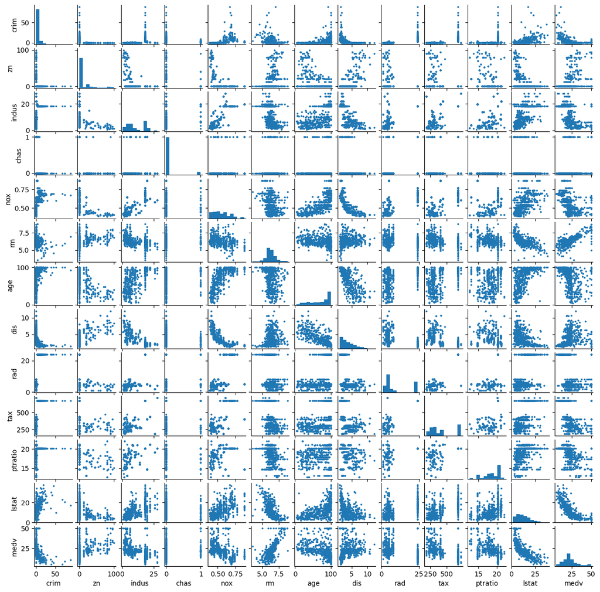

```python
g = sns.PairGrid(boston)
g.map_upper(plt.scatter, s=3)
g.map_diag(plt.hist)
g.map_lower(plt.scatter, s=3)
g.fig.set_size_inches(12, 12)
```

Based on the scatter plot matrix, we can observe the following:

1. Some variables show clear correlations, for example:
- rm (average number of rooms) is positively correlated with medv (median house value)
- lstat (percentage of lower status population) is negatively correlated with medv
- tax (property tax rate) is positively correlated with rad (accessibility to radial highways)
2. Some variables have skewed distributions, such as crim (per capita crime rate) and tax showing right-skewed distributions
3. Non-linear relationships exist between some variables, like dis (weighted distances to employment centers) and nox (nitric oxides concentration)
4. Some variables like chas (Charles River dummy variable) are binary
5. There are outliers present, especially in the crim and tax variables

(d) Are any of the predictors associated with per capita crime rate? If so, explain the relationship.

```python
correlations = boston.corrwith(boston['crim']).sort_values()
correlations
```

```
medv      -0.388305
dis       -0.379670
rm        -0.219247
zn        -0.200469
chas      -0.055892
ptratio    0.289946
age        0.352734
indus      0.406583
nox        0.420972
lstat      0.455621
tax        0.582764
rad        0.625505
crim       1.000000
dtype: float64
```

Based on the correlation analysis results, we can observe the following predictors associated with the per capita crime rate (crim):

1. rad (index of accessibility to radial highways) shows a **strong positive correlation** (0.63) with crim, suggesting that areas with better highway access may have higher crime rates.
2. tax (property tax rate) also exhibits a **strong positive correlation** (0.58) with crim, which might reflect the relationship between socioeconomic conditions in high-tax areas and crime rates.
3. lstat (percentage of lower status population) shows a **moderate positive correlation** (0.46) with crim, indicating that areas with a higher proportion of lower-income residents may face higher crime rates.
4. nox (nitric oxides concentration) and indus (proportion of non-retail business acres) show **moderate positive correlations** (0.42 and 0.41 respectively) with crim, possibly reflecting the relationship between industrialization levels and crime rates.
5. age (proportion of owner-occupied units built prior to 1940) has a **weak positive correlation** (0.35) with crim, suggesting that older neighborhoods might face slightly higher crime rates.
6. dis (weighted distances to employment centers) shows a **weak negative correlation** (-0.38) with crim, indicating that areas farther from employment centers might have slightly lower crime rates.
7. rm (average number of rooms) has a **weak negative correlation** (-0.22) with crim, possibly reflecting that areas with better housing conditions might have slightly lower crime rates.

(e) Do any of the suburbs of Boston appear to have particularly high crime rates? Tax rates? Pupil-teacher ratios? Comment on the range of each predictor.

```python
boston.loc[boston['crim'].nlargest(5).index]
```

|  | crim | zn | indus | chas | nox | rm | age | dis | rad | tax | ptratio | lstat | medv |
| --- | --- | --- | --- | --- | --- | --- | --- | --- | --- | --- | --- | --- | --- |
| 380 | 88.9762 | 0.0 | 18.1 | 0 | 0.671 | 6.968 | 91.9 | 1.4165 | 24 | 666 | 20.2 | 17.21 | 10.4 |
| 418 | 73.5341 | 0.0 | 18.1 | 0 | 0.679 | 5.957 | 100.0 | 1.8026 | 24 | 666 | 20.2 | 20.62 | 8.8 |
| 405 | 67.9208 | 0.0 | 18.1 | 0 | 0.693 | 5.683 | 100.0 | 1.4254 | 24 | 666 | 20.2 | 22.98 | 5.0 |
| 410 | 51.1358 | 0.0 | 18.1 | 0 | 0.597 | 5.757 | 100.0 | 1.4130 | 24 | 666 | 20.2 | 10.11 | 15.0 |
| 414 | 45.7461 | 0.0 | 18.1 | 0 | 0.693 | 4.519 | 100.0 | 1.6582 | 24 | 666 | 20.2 | 36.98 | 7.0 |

```python
boston.loc[boston['tax'].nlargest(5).index]
```

|  | crim | zn | indus | chas | nox | rm | age | dis | rad | tax | ptratio | lstat | medv |
| --- | --- | --- | --- | --- | --- | --- | --- | --- | --- | --- | --- | --- | --- |
| 488 | 0.15086 | 0.0 | 27.74 | 0 | 0.609 | 5.454 | 92.7 | 1.8209 | 4 | 711 | 20.1 | 18.06 | 15.2 |
| 489 | 0.18337 | 0.0 | 27.74 | 0 | 0.609 | 5.414 | 98.3 | 1.7554 | 4 | 711 | 20.1 | 23.97 | 7.0 |
| 490 | 0.20746 | 0.0 | 27.74 | 0 | 0.609 | 5.093 | 98.0 | 1.8226 | 4 | 711 | 20.1 | 29.68 | 8.1 |
| 491 | 0.10574 | 0.0 | 27.74 | 0 | 0.609 | 5.983 | 98.8 | 1.8681 | 4 | 711 | 20.1 | 18.07 | 13.6 |
| 492 | 0.11132 | 0.0 | 27.74 | 0 | 0.609 | 5.983 | 83.5 | 2.1099 | 4 | 711 | 20.1 | 13.35 | 20.1 |

```python
boston.loc[boston['ptratio'].nlargest(5).index]
```

|  | crim | zn | indus | chas | nox | rm | age | dis | rad | tax | ptratio | lstat | medv |
| --- | --- | --- | --- | --- | --- | --- | --- | --- | --- | --- | --- | --- | --- |
| 354 | 0.04301 | 80.0 | 1.91 | 0 | 0.413 | 5.663 | 21.9 | 10.5857 | 4 | 334 | 22.0 | 8.05 | 18.2 |
| 355 | 0.10659 | 80.0 | 1.91 | 0 | 0.413 | 5.936 | 19.5 | 10.5857 | 4 | 334 | 22.0 | 5.57 | 20.6 |
| 127 | 0.25915 | 0.0 | 21.89 | 0 | 0.624 | 5.693 | 96.0 | 1.7883 | 4 | 437 | 21.2 | 17.19 | 16.2 |
| 128 | 0.32543 | 0.0 | 21.89 | 0 | 0.624 | 6.431 | 98.8 | 1.8125 | 4 | 437 | 21.2 | 15.39 | 18.0 |
| 129 | 0.88125 | 0.0 | 21.89 | 0 | 0.624 | 5.637 | 94.7 | 1.9799 | 4 | 437 | 21.2 | 18.34 | 14.3 |

```python
boston.describe()
```

|  | crim | zn | indus | chas | nox | rm | age | dis | rad | tax | ptratio | lstat | medv |
| --- | --- | --- | --- | --- | --- | --- | --- | --- | --- | --- | --- | --- | --- |
| count | 506.000000 | 506.000000 | 506.000000 | 506.000000 | 506.000000 | 506.000000 | 506.000000 | 506.000000 | 506.000000 | 506.000000 | 506.000000 | 506.000000 | 506.000000 |
| mean | 3.613524 | 11.363636 | 11.136779 | 0.069170 | 0.554695 | 6.284634 | 68.574901 | 3.795043 | 9.549407 | 408.237154 | 18.455534 | 12.653063 | 22.532806 |
| std | 8.601545 | 23.322453 | 6.860353 | 0.253994 | 0.115878 | 0.702617 | 28.148861 | 2.105710 | 8.707259 | 168.537116 | 2.164946 | 7.141062 | 9.197104 |
| min | 0.006320 | 0.000000 | 0.460000 | 0.000000 | 0.385000 | 3.561000 | 2.900000 | 1.129600 | 1.000000 | 187.000000 | 12.600000 | 1.730000 | 5.000000 |
| 25% | 0.082045 | 0.000000 | 5.190000 | 0.000000 | 0.449000 | 5.885500 | 45.025000 | 2.100175 | 4.000000 | 279.000000 | 17.400000 | 6.950000 | 17.025000 |
| 50% | 0.256510 | 0.000000 | 9.690000 | 0.000000 | 0.538000 | 6.208500 | 77.500000 | 3.207450 | 5.000000 | 330.000000 | 19.050000 | 11.360000 | 21.200000 |
| 75% | 3.677083 | 12.500000 | 18.100000 | 0.000000 | 0.624000 | 6.623500 | 94.075000 | 5.188425 | 24.000000 | 666.000000 | 20.200000 | 16.955000 | 25.000000 |
| max | 88.976200 | 100.000000 | 27.740000 | 1.000000 | 0.871000 | 8.780000 | 100.000000 | 12.126500 | 24.000000 | 711.000000 | 22.000000 | 37.970000 | 50.000000 |

- Regarding **crime rates**, a few suburbs stand out with particularly high rates, with the highest reaching 88.9762. The crime rate distribution is highly uneven, ranging from 0.00632 to 88.9762, although most suburbs have relatively low crime rates, with a median of 0.25651.
- In terms of **tax rates**, some suburbs have noticeably higher rates, peaking at 711. The tax rate distribution is more uniform, spanning from 187 to 711, with a median of 330, indicating that most suburbs have moderate tax rates.
- **The pupil-teacher ratio** shows less variation, ranging from 12.6 to 22.0, with a median of 19.05, suggesting that most suburbs have relatively similar ratios without any particularly high outliers. Overall, the crime rate exhibits the most significant disparities among the suburbs, while the pupil-teacher ratio shows the least variation. These data reflect considerable socioeconomic differences across Boston's suburbs.

(f) How many of the suburbs in this data set bound the Charles river?

```python
boston['chas'].value_counts()[1]
```

```
35
```

(g) What is the median pupil-teacher ratio among the towns in this data set?

```python
boston['ptratio'].median()
```

```
19.05
```

(h) Which suburb of Boston has lowest median value of owneroccupied homes? What are the values of the other predictors for that suburb, and how do those values compare to the overall ranges for those predictors? Comment on your findings.

```python
boston['medv'].idxmin()
```

```
398
```

```python
a = boston.describe()
a.loc['range'] = a.loc['max'] - a.loc['min']
a.loc[398] = boston.iloc[398]
a
```

|  | crim | zn | indus | chas | nox | rm | age | dis | rad | tax | ptratio | lstat | medv |
| --- | --- | --- | --- | --- | --- | --- | --- | --- | --- | --- | --- | --- | --- |
| count | 506.000000 | 506.000000 | 506.000000 | 506.000000 | 506.000000 | 506.000000 | 506.000000 | 506.000000 | 506.000000 | 506.000000 | 506.000000 | 506.000000 | 506.000000 |
| mean | 3.613524 | 11.363636 | 11.136779 | 0.069170 | 0.554695 | 6.284634 | 68.574901 | 3.795043 | 9.549407 | 408.237154 | 18.455534 | 12.653063 | 22.532806 |
| std | 8.601545 | 23.322453 | 6.860353 | 0.253994 | 0.115878 | 0.702617 | 28.148861 | 2.105710 | 8.707259 | 168.537116 | 2.164946 | 7.141062 | 9.197104 |
| min | 0.006320 | 0.000000 | 0.460000 | 0.000000 | 0.385000 | 3.561000 | 2.900000 | 1.129600 | 1.000000 | 187.000000 | 12.600000 | 1.730000 | 5.000000 |
| 25% | 0.082045 | 0.000000 | 5.190000 | 0.000000 | 0.449000 | 5.885500 | 45.025000 | 2.100175 | 4.000000 | 279.000000 | 17.400000 | 6.950000 | 17.025000 |
| 50% | 0.256510 | 0.000000 | 9.690000 | 0.000000 | 0.538000 | 6.208500 | 77.500000 | 3.207450 | 5.000000 | 330.000000 | 19.050000 | 11.360000 | 21.200000 |
| 75% | 3.677083 | 12.500000 | 18.100000 | 0.000000 | 0.624000 | 6.623500 | 94.075000 | 5.188425 | 24.000000 | 666.000000 | 20.200000 | 16.955000 | 25.000000 |
| max | 88.976200 | 100.000000 | 27.740000 | 1.000000 | 0.871000 | 8.780000 | 100.000000 | 12.126500 | 24.000000 | 711.000000 | 22.000000 | 37.970000 | 50.000000 |
| range | 88.969880 | 100.000000 | 27.280000 | 1.000000 | 0.486000 | 5.219000 | 97.100000 | 10.996900 | 23.000000 | 524.000000 | 9.400000 | 36.240000 | 45.000000 |
| 398 | 38.351800 | 0.000000 | 18.100000 | 0.000000 | 0.693000 | 5.453000 | 100.000000 | 1.489600 | 24.000000 | 666.000000 | 20.200000 | 30.590000 | 5.000000 |

The suburb with the lowest median value is 398. Relative to the other towns, this suburb has high crim, zn below quantile 75%, above mean indus, does not bound the chas, above mean nox, rm below quantile 25%, maximum age, dis near to the minimum value, maximum rad, tax in quantile 75%, ptratio as well and lstat above quantile 75%.

(i) In this data set, how many of the suburbs average more than seven rooms per dwelling? More than eight rooms per dwelling? Comment on the suburbs that average more than eight rooms per dwelling.

```python
# Calculate the number of suburbs with more than 7 rooms per dwelling on average
suburbs_over_7 = (boston['rm'] > 7).sum()

# Calculate the number of suburbs with more than 8 rooms per dwelling on average
suburbs_over_8 = (boston['rm'] > 8).sum()

print(f"Number of suburbs averaging more than 7 rooms per dwelling: {suburbs_over_7}")
print(f"Number of suburbs averaging more than 8 rooms per dwelling: {suburbs_over_8}")

# Get data for suburbs averaging more than 8 rooms per dwelling
suburbs_over_8_data = boston[boston['rm'] > 8]

print("\nCharacteristics of suburbs averaging more than 8 rooms per dwelling:")
print(suburbs_over_8_data.describe())
```

```
Number of suburbs averaging more than 7 rooms per dwelling: 64
Number of suburbs averaging more than 8 rooms per dwelling: 13

Characteristics of suburbs averaging more than 8 rooms per dwelling:
            crim         zn      indus       chas        nox         rm  \
count  13.000000  13.000000  13.000000  13.000000  13.000000  13.000000
mean    0.718795  13.615385   7.078462   0.153846   0.539238   8.348538
std     0.901640  26.298094   5.392767   0.375534   0.092352   0.251261
min     0.020090   0.000000   2.680000   0.000000   0.416100   8.034000
25%     0.331470   0.000000   3.970000   0.000000   0.504000   8.247000
50%     0.520140   0.000000   6.200000   0.000000   0.507000   8.297000
75%     0.578340  20.000000   6.200000   0.000000   0.605000   8.398000
max     3.474280  95.000000  19.580000   1.000000   0.718000   8.780000

             age        dis        rad         tax    ptratio      lstat  \
count  13.000000  13.000000  13.000000   13.000000  13.000000  13.000000
mean   71.538462   3.430192   7.461538  325.076923  16.361538   4.310000
std    24.608723   1.883955   5.332532  110.971063   2.410580   1.373566
min     8.400000   1.801000   2.000000  224.000000  13.000000   2.470000
25%    70.400000   2.288500   5.000000  264.000000  14.700000   3.320000
50%    78.300000   2.894400   7.000000  307.000000  17.400000   4.140000
75%    86.500000   3.651900   8.000000  307.000000  17.400000   5.120000
max    93.900000   8.906700  24.000000  666.000000  20.200000   7.440000

            medv
count  13.000000
mean   44.200000
std     8.092383
min    21.900000
25%    41.700000
50%    48.300000
75%    50.000000
max    50.000000
```

Based on the analysis results, we can make the following comments about the suburbs with an average of more than 8 rooms per dwelling:

1. Lower crime rate (crim), indicating better safety conditions in these areas.
2. Lower proportion of non-retail business acres (indus), suggesting these areas are primarily residential with less commercial activity.
3. Lower percentage of lower status population (lstat), implying that residents in these suburbs generally have better economic conditions.

# Chapter 3

### question 8

This question involves the use of simple linear regression on the Auto data set.

(a) Use the sm.OLS() function to perform a simple linear regression with mpg as the response and horsepower as the predictor. Use the summarize() function to print the results. Comment on the output. For example: i. Is there a relationship between the predictor and the response? ii. How strong is the relationship between the predictor and the response? iii. Is the relationship between the predictor and the response positive or negative? iv. What is the predicted mpg associated with a horsepower of 98? What are the associated 95 % confidence and prediction intervals?

```python
import pandas as pd
import numpy as np
import seaborn as sns
import matplotlib.pyplot as plt
import statsmodels.formula.api as smf
import statsmodels.api as sm
```

```python
# load data
df = pd.read_csv('auto.csv')
df.head()
```

|  | mpg | cylinders | displacement | horsepower | weight | acceleration | year | origin | name |
| --- | --- | --- | --- | --- | --- | --- | --- | --- | --- |
| 0 | 18.0 | 8 | 307.0 | 130 | 3504 | 12.0 | 70 | 1 | chevrolet chevelle malibu |
| 1 | 15.0 | 8 | 350.0 | 165 | 3693 | 11.5 | 70 | 1 | buick skylark 320 |
| 2 | 18.0 | 8 | 318.0 | 150 | 3436 | 11.0 | 70 | 1 | plymouth satellite |
| 3 | 16.0 | 8 | 304.0 | 150 | 3433 | 12.0 | 70 | 1 | amc rebel sst |
| 4 | 17.0 | 8 | 302.0 | 140 | 3449 | 10.5 | 70 | 1 | ford torino |

```python
# prepare data for modelling (training set)
X_train = df['horsepower']
y_train = df['mpg']
```

```python
X_train.head()
```

```
0    130
1    165
2    150
3    150
4    140
Name: horsepower, dtype: object
```

```python
y_train.head()
```

```
0    18.0
1    15.0
2    18.0
3    16.0
4    17.0
Name: mpg, dtype: float64
```

```python
X_train.unique()
```

```
array(['130', '165', '150', '140', '198', '220', '215', '225', '190',
       '170', '160', '95', '97', '85', '88', '46', '87', '90', '113',
       '200', '210', '193', '?', '100', '105', '175', '153', '180', '110',
       '72', '86', '70', '76', '65', '69', '60', '80', '54', '208', '155',
       '112', '92', '145', '137', '158', '167', '94', '107', '230', '49',
       '75', '91', '122', '67', '83', '78', '52', '61', '93', '148',
       '129', '96', '71', '98', '115', '53', '81', '79', '120', '152',
       '102', '108', '68', '58', '149', '89', '63', '48', '66', '139',
       '103', '125', '133', '138', '135', '142', '77', '62', '132', '84',
       '64', '74', '116', '82'], dtype=object)
```

since there is a strange item -- "?", we hope to delete it

```python
droplist = X_train[X_train == '?'].index
X_train = X_train.drop(droplist)
y_train = y_train.drop(droplist)
X_train.unique()
```

```
array(['130', '165', '150', '140', '198', '220', '215', '225', '190',
       '170', '160', '95', '97', '85', '88', '46', '87', '90', '113',
       '200', '210', '193', '100', '105', '175', '153', '180', '110',
       '72', '86', '70', '76', '65', '69', '60', '80', '54', '208', '155',
       '112', '92', '145', '137', '158', '167', '94', '107', '230', '49',
       '75', '91', '122', '67', '83', '78', '52', '61', '93', '148',
       '129', '96', '71', '98', '115', '53', '81', '79', '120', '152',
       '102', '108', '68', '58', '149', '89', '63', '48', '66', '139',
       '103', '125', '133', '138', '135', '142', '77', '62', '132', '84',
       '64', '74', '116', '82'], dtype=object)
```

it's fine now, then check for y

```python
y_train.unique()
```

```
array([18. , 15. , 16. , 17. , 14. , 24. , 22. , 21. , 27. , 26. , 25. ,
       10. , 11. ,  9. , 28. , 19. , 12. , 13. , 23. , 30. , 31. , 35. ,
       20. , 29. , 32. , 33. , 17.5, 15.5, 14.5, 22.5, 24.5, 18.5, 29.5,
       26.5, 16.5, 31.5, 36. , 25.5, 33.5, 20.5, 30.5, 21.5, 43.1, 36.1,
       32.8, 39.4, 19.9, 19.4, 20.2, 19.2, 25.1, 20.6, 20.8, 18.6, 18.1,
       17.7, 27.5, 27.2, 30.9, 21.1, 23.2, 23.8, 23.9, 20.3, 21.6, 16.2,
       19.8, 22.3, 17.6, 18.2, 16.9, 31.9, 34.1, 35.7, 27.4, 25.4, 34.2,
       34.5, 31.8, 37.3, 28.4, 28.8, 26.8, 41.5, 38.1, 32.1, 37.2, 26.4,
       24.3, 19.1, 34.3, 29.8, 31.3, 37. , 32.2, 46.6, 27.9, 40.8, 44.3,
       43.4, 36.4, 44.6, 33.8, 32.7, 23.7, 32.4, 26.6, 25.8, 23.5, 39.1,
       39. , 35.1, 32.3, 37.7, 34.7, 34.4, 29.9, 33.7, 32.9, 31.6, 28.1,
       30.7, 24.2, 22.4, 34. , 38. , 44. ])
```

```python
d = {'horsepower':X_train.astype('float'), 'mpg':y_train}
df = pd.DataFrame(data=d)
df.head()
```

|  | horsepower | mpg |
| --- | --- | --- |
| 0 | 130.0 | 18.0 |
| 1 | 165.0 | 15.0 |
| 2 | 150.0 | 18.0 |
| 3 | 150.0 | 16.0 |
| 4 | 140.0 | 17.0 |

all fine now, than we use OLS to regress

```python
mod = smf.ols(formula='mpg ~ horsepower', data = df)
res = mod.fit()
print(res.summary())
```

```
                            OLS Regression Results
==============================================================================
Dep. Variable:                    mpg   R-squared:                       0.606
Model:                            OLS   Adj. R-squared:                  0.605
Method:                 Least Squares   F-statistic:                     599.7
Date:                Fri, 11 Oct 2024   Prob (F-statistic):           7.03e-81
Time:                        00:53:43   Log-Likelihood:                -1178.7
No. Observations:                 392   AIC:                             2361.
Df Residuals:                     390   BIC:                             2369.
Df Model:                           1
Covariance Type:            nonrobust
==============================================================================
                 coef    std err          t      P>|t|      [0.025      0.975]
------------------------------------------------------------------------------
Intercept     39.9359      0.717     55.660      0.000      38.525      41.347
horsepower    -0.1578      0.006    -24.489      0.000      -0.171      -0.145
==============================================================================
Omnibus:                       16.432   Durbin-Watson:                   0.920
Prob(Omnibus):                  0.000   Jarque-Bera (JB):               17.305
Skew:                           0.492   Prob(JB):                     0.000175
Kurtosis:                       3.299   Cond. No.                         322.
==============================================================================

Notes:
[1] Standard Errors assume that the covariance matrix of the errors is correctly specified.
```

Analysis of regression results:

i. There is a significant relationship between the predictor variable (horsepower) and the response variable (mpg). The p-value is far less than 0.05, indicating statistical significance.

ii. The R-squared value is 0.606, suggesting that horsepower explains 60.6% of the variation in mpg. This indicates a strong relationship, but other factors also influence mpg.

iii. The coefficient is negative (-0.1578), indicating an inverse relationship between horsepower and mpg. As horsepower increases, mpg decreases.

For iv:

```python
from scipy.stats import t
from math import sqrt

def interval(x, y, x0,alpha = .05):
    n = np.size(x)
    x_bar = np.mean(x)
    y_bar = np.mean(y)
    S_xx = np.sum((x-x_bar)**2)         # page 541
    S_xy = np.sum((x-x_bar)*(y-y_bar))  # page 541
    b = S_xy/S_xx                       # page 542
    a = y_bar - b*x_bar                 # page 542
    S2 = np.sum((y-a-b*x)**2)/(n-2)     # page 552
    S = sqrt(S2)
    ts = t.ppf(1-alpha/2, n-2)
    w_conf = ts*S*sqrt(1/n + (x0-x_bar)**2/S_xx)      # page 558
    w_pred = ts*S*sqrt(1 + 1/n + (x0-x_bar)**2/S_xx)  # page 559
    print("                fit \t lwr \t  upr")
    print("confidence %3.5f %3.5f %3.5f" % (a+b*x0, a+b*x0 - w_conf, a+b*x0 + w_conf))
    print("prediction %3.5f %3.5f %3.5f" % (a+b*x0, a+b*x0 - w_pred, a+b*x0 + w_pred))

x = df['horsepower']
y = df['mpg']
x0 = 98

interval(x, y, x0)
```

```
                fit 	 lwr 	  upr
confidence 24.46708 23.97308 24.96108
prediction 24.46708 14.80940 34.12476
```

(b). Plot the response and the predictor in a new set of axes ax. Use the ax.axline() method or the abline() function defined in the lab to display the least squares regression line.

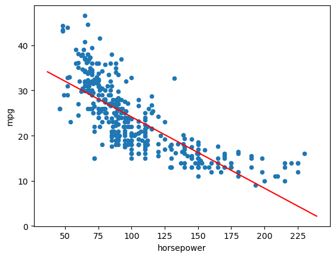

```python
def abline(ax, b, m, *args, **kwargs):
    "Add a line with slope m and intercept b to ax"
    xlim = ax.get_xlim()
    ylim = [m * xlim[0] + b, m * xlim[1] + b]
    ax.plot(xlim, ylim, *args, **kwargs)

ax = df.plot.scatter('horsepower', 'mpg')
abline(ax, res.params[0], res.params[1], 'r')
```

(c) Produce some of diagnostic plots of the least squares regression fit as described in the lab. Comment on any problems you see with the fit.

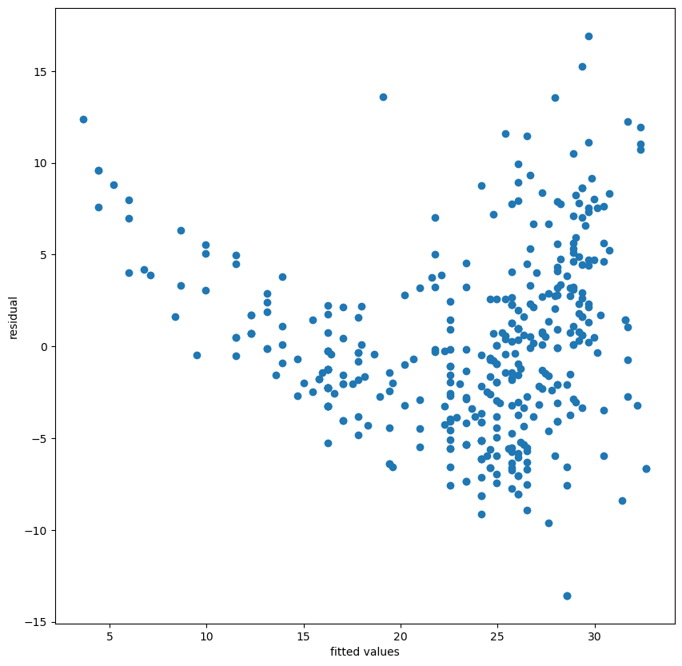

```python
## 1. the scatter plot between fitted values and residual
fig, ax = plt.subplots(figsize=(10,10))
ax.scatter(res.fittedvalues, res.resid)
ax.set_xlabel("fitted values")
ax.set_ylabel("residual")
plt.show()
```

- We can clearly see that the drawn image (residuals vs fitted values) should be non-linear. Also, the funnel shape shown in the image indicates the presence of heteroscedasticity, since the variability of residuals increase with the increase of fitting values.

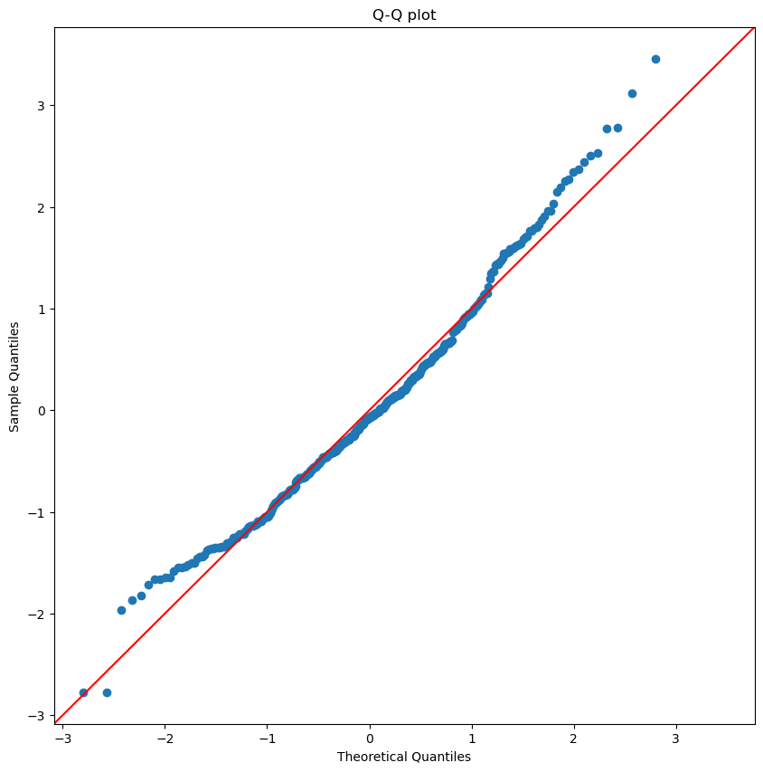

```python
# 2. Q-Q plot
fig, ax = plt.subplots(figsize=(10,10))
sm.qqplot(res.resid, line='45', fit=True, ax=ax)
ax.set_title("Q-Q plot")
plt.show()
```

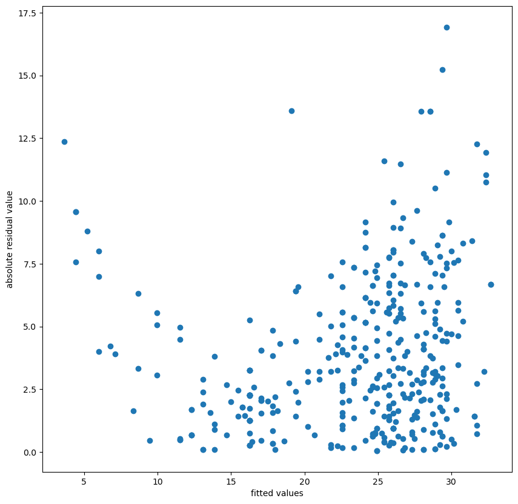

```python
# 3. Scale-Location plot of sqrt(|residuals|) against fitted values
fig, ax = plt.subplots(figsize=(10,10))
ax.scatter(res.fittedvalues, np.abs(res.resid))
ax.set_xlabel("fitted values")
ax.set_ylabel("absolute residual value")
plt.show()
```

- similar to the first graph, which do not take absolute value. It also proves that the assumption of homoscedasticity is not held.

### question 9

This question involves the use of multiple linear regression on the Auto data set.

(a) Produce a scatterplot matrix which includes all of the variables in the data set.

```python
import pandas as pd
import numpy as np
import seaborn as sns
import matplotlib.pyplot as plt
import statsmodels.formula.api as smf
import statsmodels.api as sm
```

```python
df = pd.read_csv("Auto.csv")
df
```

|  | mpg | cylinders | displacement | horsepower | weight | acceleration | year | origin | name |
| --- | --- | --- | --- | --- | --- | --- | --- | --- | --- |
| 0 | 18.0 | 8 | 307.0 | 130 | 3504 | 12.0 | 70 | 1 | chevrolet chevelle malibu |
| 1 | 15.0 | 8 | 350.0 | 165 | 3693 | 11.5 | 70 | 1 | buick skylark 320 |
| 2 | 18.0 | 8 | 318.0 | 150 | 3436 | 11.0 | 70 | 1 | plymouth satellite |
| 3 | 16.0 | 8 | 304.0 | 150 | 3433 | 12.0 | 70 | 1 | amc rebel sst |
| 4 | 17.0 | 8 | 302.0 | 140 | 3449 | 10.5 | 70 | 1 | ford torino |
| ... | ... | ... | ... | ... | ... | ... | ... | ... | ... |
| 392 | 27.0 | 4 | 140.0 | 86 | 2790 | 15.6 | 82 | 1 | ford mustang gl |
| 393 | 44.0 | 4 | 97.0 | 52 | 2130 | 24.6 | 82 | 2 | vw pickup |
| 394 | 32.0 | 4 | 135.0 | 84 | 2295 | 11.6 | 82 | 1 | dodge rampage |
| 395 | 28.0 | 4 | 120.0 | 79 | 2625 | 18.6 | 82 | 1 | ford ranger |
| 396 | 31.0 | 4 | 119.0 | 82 | 2720 | 19.4 | 82 | 1 | chevy s-10 |

397 rows × 9 columns

|  | mpg | cylinders | displacement | weight | acceleration | year | origin |
| --- | --- | --- | --- | --- | --- | --- | --- |
| mpg | 1.000000 | -0.776260 | -0.804443 | -0.831739 | 0.422297 | 0.581469 | 0.563698 |
| cylinders | -0.776260 | 1.000000 | 0.950920 | 0.897017 | -0.504061 | -0.346717 | -0.564972 |
| displacement | -0.804443 | 0.950920 | 1.000000 | 0.933104 | -0.544162 | -0.369804 | -0.610664 |
| weight | -0.831739 | 0.897017 | 0.933104 | 1.000000 | -0.419502 | -0.307900 | -0.581265 |
| acceleration | 0.422297 | -0.504061 | -0.544162 | -0.419502 | 1.000000 | 0.282901 | 0.210084 |
| year | 0.581469 | -0.346717 | -0.369804 | -0.307900 | 0.282901 | 1.000000 | 0.184314 |
| origin | 0.563698 | -0.564972 | -0.610664 | -0.581265 | 0.210084 | 0.184314 | 1.000000 |

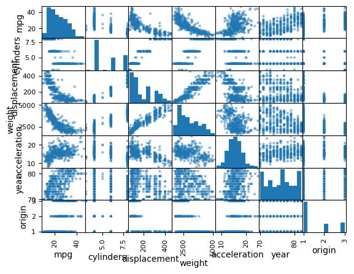

```python
pd.plotting.scatter_matrix(df)
df.corr(numeric_only=True)
```

(b) Compute the matrix of correlations between the variables using the DataFrame.corr() method

```
                   mpg  cylinders  displacement  horsepower    weight  \
mpg           1.000000  -0.776260     -0.804443   -0.778427 -0.831739
cylinders    -0.776260   1.000000      0.950920    0.842983  0.897017
displacement -0.804443   0.950920      1.000000    0.897257  0.933104
horsepower   -0.778427   0.842983      0.897257    1.000000  0.864538
weight       -0.831739   0.897017      0.933104    0.864538  1.000000
acceleration  0.422297  -0.504061     -0.544162   -0.689196 -0.419502
year          0.581469  -0.346717     -0.369804   -0.416361 -0.307900
origin        0.563698  -0.564972     -0.610664   -0.455171 -0.581265

              acceleration      year    origin
mpg               0.422297  0.581469  0.563698
cylinders        -0.504061 -0.346717 -0.564972
displacement     -0.544162 -0.369804 -0.610664
horsepower       -0.689196 -0.416361 -0.455171
weight           -0.419502 -0.307900 -0.581265
acceleration      1.000000  0.282901  0.210084
year              0.282901  1.000000  0.184314
origin            0.210084  0.184314  1.000000
```

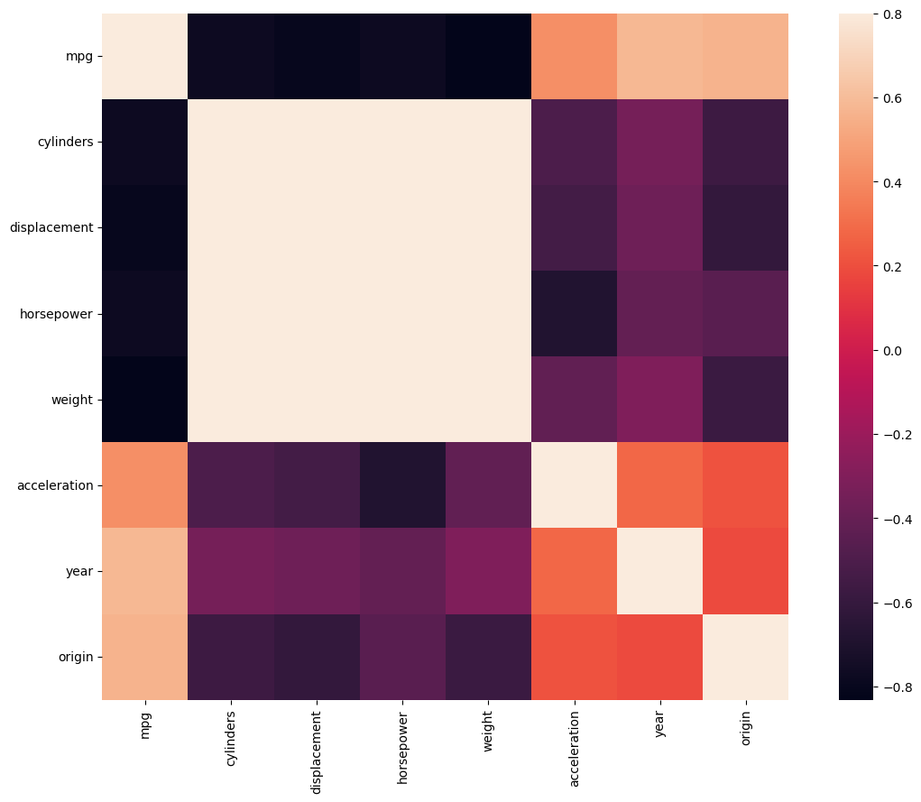

```python
df['horsepower'] = pd.to_numeric(df['horsepower'], errors='coerce')
numeric_columns = df.select_dtypes(include=[np.number]).columns
corrmat = df[numeric_columns].corr()
print(corrmat)
f, ax = plt.subplots(figsize=(12, 9))
sns.heatmap(corrmat, vmax=.8, square=True)
f.tight_layout()
```

(c) Use the sm.OLS() function to perform a multiple linear regression with mpg as the response and all other variables except name as the predictors. Use the summarize() function to print the results. Comment on the output. For instance: i. Is there a relationship between the predictors and the response? Use the anova_lm() function from statsmodels to answer this question. ii. Which predictors appear to have a statistically significant relationship to the response? iii. What does the coefficient for the year variable suggest?

```python
reg = smf.ols('mpg ~ cylinders + displacement + horsepower + weight + acceleration + year + origin', df).fit()
reg.summary()
```

OLS Regression Results

| Dep. Variable: | mpg | R-squared: | 0.821 |
| --- | --- | --- | --- |
| Model: | OLS | Adj. R-squared: | 0.818 |
| Method: | Least Squares | F-statistic: | 252.4 |
| Date: | Fri, 11 Oct 2024 | Prob (F-statistic): | 2.04e-139 |
| Time: | 01:17:00 | Log-Likelihood: | -1023.5 |
| No. Observations: | 392 | AIC: | 2063. |
| Df Residuals: | 384 | BIC: | 2095. |
| Df Model: | 7 |  |  |
| Covariance Type: | nonrobust |  |  |

|  | coef | std err | t | P>\|t\| | [0.025 | 0.975] |
| --- | --- | --- | --- | --- | --- | --- |
| Intercept | -17.2184 | 4.644 | -3.707 | 0.000 | -26.350 | -8.087 |
| cylinders | -0.4934 | 0.323 | -1.526 | 0.128 | -1.129 | 0.142 |
| displacement | 0.0199 | 0.008 | 2.647 | 0.008 | 0.005 | 0.035 |
| horsepower | -0.0170 | 0.014 | -1.230 | 0.220 | -0.044 | 0.010 |
| weight | -0.0065 | 0.001 | -9.929 | 0.000 | -0.008 | -0.005 |
| acceleration | 0.0806 | 0.099 | 0.815 | 0.415 | -0.114 | 0.275 |
| year | 0.7508 | 0.051 | 14.729 | 0.000 | 0.651 | 0.851 |
| origin | 1.4261 | 0.278 | 5.127 | 0.000 | 0.879 | 1.973 |

| Omnibus: | 31.906 | Durbin-Watson: | 1.309 |
| --- | --- | --- | --- |
| Prob(Omnibus): | 0.000 | Jarque-Bera (JB): | 53.100 |
| Skew: | 0.529 | Prob(JB): | 2.95e-12 |
| Kurtosis: | 4.460 | Cond. No. | 8.59e+04 |

Notes:  
[1] Standard Errors assume that the covariance matrix of the errors is correctly specified.  
[2] The condition number is large, 8.59e+04. This might indicate that there are  
strong multicollinearity or other numerical problems.

Based on the regression results:

i. There appears to be a significant relationship between the predictors and the response (mpg). The F-statistic is large (252.4) with a very low p-value, indicating the model as a whole is statistically significant.

ii. Several predictors show statistically significant relationships with mpg, including weight, year, and origin (p-values < 0.05). Displacement also appears significant. Cylinders, horsepower, and acceleration do not show strong statistical significance in this model.

iii. The coefficient for the year variable (0.7508) suggests that, on average, for each year increase, the mpg increases by about 0.75, holding other variables constant. This indicates a trend of improving fuel efficiency over time.

(d) Produce some of diagnostic plots of the linear regression fit as described in the lab. Comment on any problems you see with the fit. Do the residual plots suggest any unusually large outliers? Does the leverage plot identify any observations with unusually high leverage?

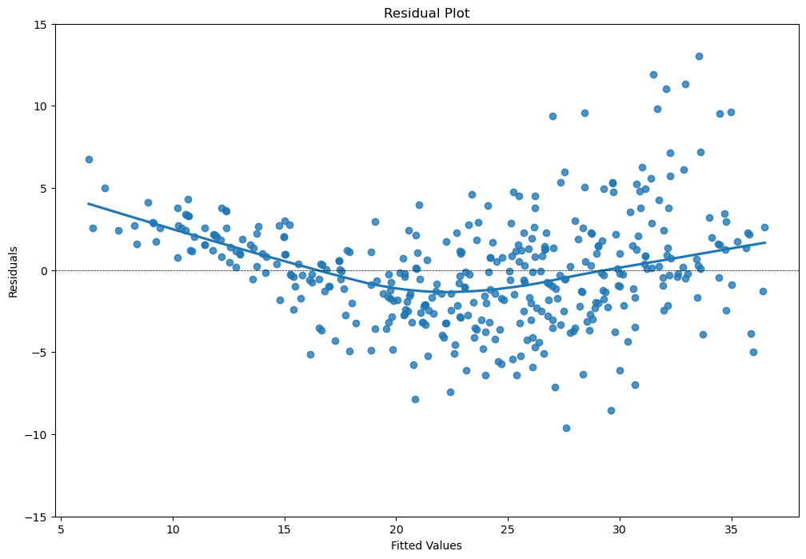

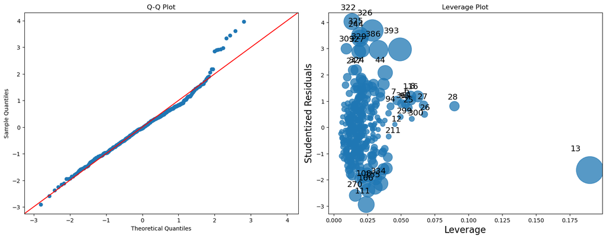

```python
# Diagnostic plots
# Distribution of residuals
plt.figure(figsize=(12, 8))
plt.ylim(-15, 15)
sns.regplot(x=reg.fittedvalues, y=reg.resid, lowess=True)
plt.axhline(y=0, linewidth=0.5, linestyle='dashed', color='black')
plt.xlabel('Fitted Values')
plt.ylabel('Residuals')
plt.title('Residual Plot')

# Add Q-Q plot
fig, (ax1, ax2) = plt.subplots(1, 2, figsize=(15, 6))
sm.qqplot(reg.resid, line='45', fit=True, ax=ax1)
ax1.set_title('Q-Q Plot')

# Add leverage plot
sm.graphics.influence_plot(reg, ax=ax2, criterion="cooks")
ax2.set_title('Leverage Plot')

plt.tight_layout()
plt.show()
```

(e) Fit some models with interactions as described in the lab. Do any interactions appear to be statistically significant?

```python
predictors = ' + '.join(df.columns.difference(['name', 'mpg']))
model = smf.ols(formula=f'mpg ~ {predictors} + horsepower*cylinders + horsepower*year', data=df)
results = model.fit()
print(results.summary())

interactions = results.pvalues[['horsepower:cylinders', 'horsepower:year']]
significant_interactions = interactions[interactions < 0.05]
significant_interactions
```

```
                            OLS Regression Results
==============================================================================
Dep. Variable:                    mpg   R-squared:                       0.870
Model:                            OLS   Adj. R-squared:                  0.867
Method:                 Least Squares   F-statistic:                     283.1
Date:                Fri, 11 Oct 2024   Prob (F-statistic):          5.43e-163
Time:                        01:26:01   Log-Likelihood:                -961.89
No. Observations:                 392   AIC:                             1944.
Df Residuals:                     382   BIC:                             1983.
Df Model:                           9
Covariance Type:            nonrobust
========================================================================================
                           coef    std err          t      P>|t|      [0.025      0.975]
----------------------------------------------------------------------------------------
Intercept              -40.8773     12.176     -3.357      0.001     -64.817     -16.937
acceleration            -0.1742      0.088     -1.985      0.048      -0.347      -0.002
cylinders               -3.0837      0.516     -5.971      0.000      -4.099      -2.068
displacement            -0.0048      0.007     -0.713      0.476      -0.018       0.008
horsepower               0.2260      0.119      1.897      0.059      -0.008       0.460
origin                   0.8834      0.243      3.634      0.000       0.405       1.361
weight                  -0.0038      0.001     -6.294      0.000      -0.005      -0.003
year                     1.3597      0.139      9.771      0.000       1.086       1.633
horsepower:cylinders     0.0308      0.004      7.336      0.000       0.023       0.039
horsepower:year         -0.0065      0.001     -4.696      0.000      -0.009      -0.004
==============================================================================
Omnibus:                       39.241   Durbin-Watson:                   1.647
Prob(Omnibus):                  0.000   Jarque-Bera (JB):               72.217
Skew:                           0.596   Prob(JB):                     2.08e-16
Kurtosis:                       4.732   Cond. No.                     7.54e+05
==============================================================================

Notes:
[1] Standard Errors assume that the covariance matrix of the errors is correctly specified.
[2] The condition number is large, 7.54e+05. This might indicate that there are
strong multicollinearity or other numerical problems.
```

```
horsepower:cylinders    1.331914e-12
horsepower:year         3.710540e-06
dtype: float64
```

Based on the results, we can observe that:

1. The interaction between horsepower and cylinders is statistically significant (p-value < 0.05).
2. The interaction between horsepower and year is also statistically significant (p-value < 0.05).

These significant interactions suggest that:

1. The effect of horsepower on mpg varies depending on the number of cylinders.
2. The effect of horsepower on mpg changes over different years.

(f) Try a few different transformations of the variables, such as log(X), 'X, X2. Comment on your findings

```python
predictors = ' + '.join(df.columns.difference(['name','mpg']))
result = smf.ols('mpg ~ {} + horsepower*cylinders + np.power(horsepower,2)'.format(predictors),data = df).fit()
print(result.summary())
```

```
                            OLS Regression Results
==============================================================================
Dep. Variable:                    mpg   R-squared:                       0.863
Model:                            OLS   Adj. R-squared:                  0.860
Method:                 Least Squares   F-statistic:                     267.4
Date:                Fri, 11 Oct 2024   Prob (F-statistic):          6.47e-159
Time:                        01:29:28   Log-Likelihood:                -971.55
No. Observations:                 392   AIC:                             1963.
Df Residuals:                     382   BIC:                             2003.
Df Model:                           9
Covariance Type:            nonrobust
===========================================================================================
                              coef    std err          t      P>|t|      [0.025      0.975]
-------------------------------------------------------------------------------------------
Intercept                  10.7462      4.937      2.177      0.030       1.040      20.453
acceleration               -0.2361      0.099     -2.392      0.017      -0.430      -0.042
cylinders                  -3.2075      0.818     -3.920      0.000      -4.816      -1.599
displacement               -0.0048      0.007     -0.663      0.508      -0.019       0.009
horsepower                 -0.3386      0.034    -10.048      0.000      -0.405      -0.272
origin                      0.8978      0.249      3.603      0.000       0.408       1.388
weight                     -0.0035      0.001     -5.310      0.000      -0.005      -0.002
year                        0.7373      0.045     16.459      0.000       0.649       0.825
horsepower:cylinders        0.0312      0.007      4.664      0.000       0.018       0.044
np.power(horsepower, 2)     0.0003      0.000      1.619      0.106   -6.39e-05       0.001
==============================================================================
Omnibus:                       39.733   Durbin-Watson:                   1.608
Prob(Omnibus):                  0.000   Jarque-Bera (JB):               72.555
Skew:                           0.605   Prob(JB):                     1.76e-16
Kurtosis:                       4.725   Cond. No.                     5.38e+05
==============================================================================

Notes:
[1] Standard Errors assume that the covariance matrix of the errors is correctly specified.
[2] The condition number is large, 5.38e+05. This might indicate that there are
strong multicollinearity or other numerical problems.
```

Additionally, as mentioned in the instructions, we can explore other transformations such as log(X) or square root of X for different variables. These transformations might reveal further insights into the relationships between the predictors and mpg, potentially improving the model's performance and our understanding of the underlying patterns in the data.